# Topic 1 Exercises

# Aveline Marshall

## Discussion Questions

### ISL 2.4.1

1. (The sample size n is incredibly large, and the number of predictors p is small.) In this case, we would generally expect the performance of a flexible statistical learning method to be better than an inflexible method. This is because the large sample size allows the flexible method to better fit the data than the inflexible method.
2. (The number of predictors p is extremely large, and the number of observations n is small.) In this case, we would generally expect the performance of a flexible statistical learning method to be worse than the inflexible method because the flexible method would lead to overfitting due to the small sample size.
3. (The relationship between the predictors and response is highly non-linear.) In this case, we would generally expect the performance of the flexible statistical learning method to be better than the inflexible method because the flexibility allows it to better fit the data.
4. (The variance of the error terms is extremely high.) In this case, we would generally expect the performance of the flexible statistical learning method to be worse than the inflexible method because the large variance of the error terms causes the flexible models to capture too much of the noise in the data.

### ISL 2.4.3

2. Bias decreases with higher flexibility. For this reason, the squared bias curve decreases at at a decreasing rate until it reaches some minimum value. Variance tends to increase with higher flexibility. For this reason, the variance curve is increasing at an increasing rate. The training error curve decreases as the flexibility increases due to the fact that the curve better fits the data. The test error curve is U-shaped. This is because as the flexibility increases, the test error drops to a certain minimum value. However, after that minimum point, the training error starts to rise as the more flexible models start to overfit the data. The Bayes (or irreducible) error curves is constant and is thus represented by a horizoatal line.

### ISL 2.4.6

Describe the differences between a parametric and non-parametric statistical learning approach. What are the advantages of a parametric approach to regression or classification (as opposed to a non-parametric approach)? What are its disadvantages?

Non-parametric methods do not make explicit assumptions about the functional form of f. They seek an estimate of f that gets as close to the data points as possible withough being too rough or wiggly. On the other hand, parametric methods reduce the problem of estimating f down to one by estimating a set of parameters. An advantage of a parametric approach to regression or classification is that the parametric approach is more flexible and can thus fit more kinds of data. The parametric approach can be used with a simple model whereas a non-parametric approach requires lots of parameters and observations. Some disadvantages of the parametric approach are that it might overfit the data and requires more assumptions, which could lead to errors.

## Computing Assignment

### ISL 2.4.8

```r
college <- read.csv("/home/local/MAC/jpark2/Math-253-Assignments/College.csv", header = TRUE)
```

2. SKIP

```r
#rownames(college) <- college[,1]
#fix(college)
```

```r
#college <- college[ ,-1]
#fix(college)
```

```r
summary(college)
```

```
##                             X       Private        Apps
##  Abilene Christian University:  1   No :212   Min.   :   81
##  Adelphi University          :  1   Yes:565   1st Qu.:  776
##  Adrian College              :  1             Median : 1558
##  Agnes Scott College         :  1             Mean   : 3002
##  Alaska Pacific University   :  1             3rd Qu.: 3624
##  Albertson College           :  1             Max.   :48094
##  (Other)                     :771
##      Accept          Enroll       Top10perc       Top25perc
##  Min.   :   72   Min.   :  35   Min.   : 1.00   Min.   :  9.0
##  1st Qu.:  604   1st Qu.: 242   1st Qu.:15.00   1st Qu.: 41.0
##  Median : 1110   Median : 434   Median :23.00   Median : 54.0
##  Mean   : 2019   Mean   : 780   Mean   :27.56   Mean   : 55.8
##  3rd Qu.: 2424   3rd Qu.: 902   3rd Qu.:35.00   3rd Qu.: 69.0
##  Max.   :26330   Max.   :6392   Max.   :96.00   Max.   :100.0
##
##   F.Undergrad     P.Undergrad         Outstate       Room.Board
##  Min.   :  139   Min.   :    1.0   Min.   : 2340   Min.   :1780
##  1st Qu.:  992   1st Qu.:   95.0   1st Qu.: 7320   1st Qu.:3597
##  Median : 1707   Median :  353.0   Median : 9990   Median :4200
##  Mean   : 3700   Mean   :  855.3   Mean   :10441   Mean   :4358
##  3rd Qu.: 4005   3rd Qu.:  967.0   3rd Qu.:12925   3rd Qu.:5050
##  Max.   :31643   Max.   :21836.0   Max.   :21700   Max.   :8124
##
##      Books           Personal         PhD            Terminal
##  Min.   :  96.0   Min.   : 250   Min.   :  8.00   Min.   : 24.0
##  1st Qu.: 470.0   1st Qu.: 850   1st Qu.: 62.00   1st Qu.: 71.0
##  Median : 500.0   Median :1200   Median : 75.00   Median : 82.0
##  Mean   : 549.4   Mean   :1341   Mean   : 72.66   Mean   : 79.7
##  3rd Qu.: 600.0   3rd Qu.:1700   3rd Qu.: 85.00   3rd Qu.: 92.0
##  Max.   :2340.0   Max.   :6800   Max.   :103.00   Max.   :100.0
##
##    S.F.Ratio      perc.alumni        Expend        Grad.Rate
##  Min.   : 2.50   Min.   : 0.00   Min.   : 3186   Min.   : 10.00
##  1st Qu.:11.50   1st Qu.:13.00   1st Qu.: 6751   1st Qu.: 53.00
##  Median :13.60   Median :21.00   Median : 8377   Median : 65.00
##  Mean   :14.09   Mean   :22.74   Mean   : 9660   Mean   : 65.46
##  3rd Qu.:16.50   3rd Qu.:31.00   3rd Qu.:10830   3rd Qu.: 78.00
##  Max.   :39.80   Max.   :64.00   Max.   :56233   Max.   :118.00
##
```

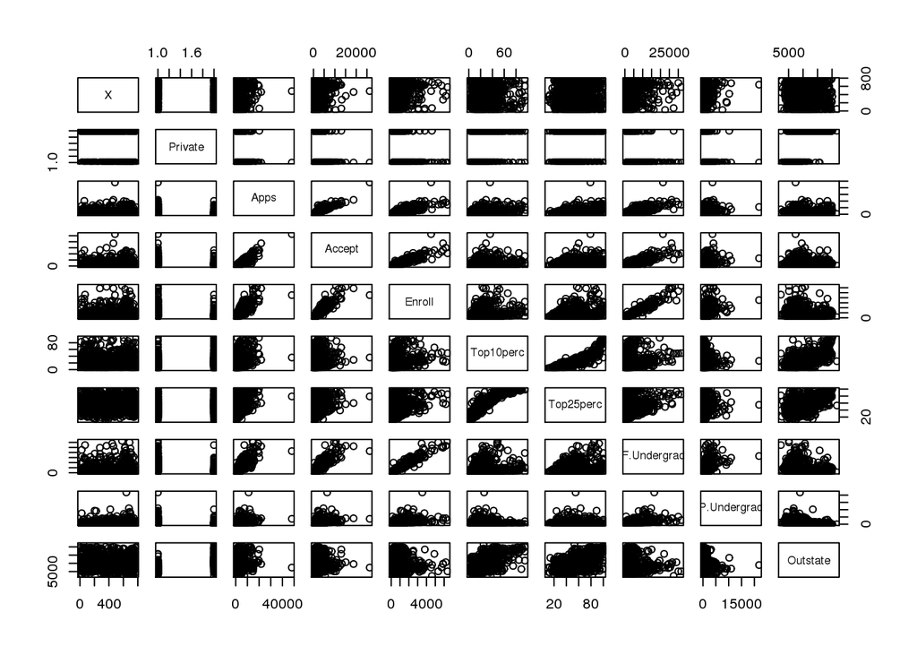

```r
pairs(college[, 1:10]) #scatterplot matrix of first ten columns of matrix
```

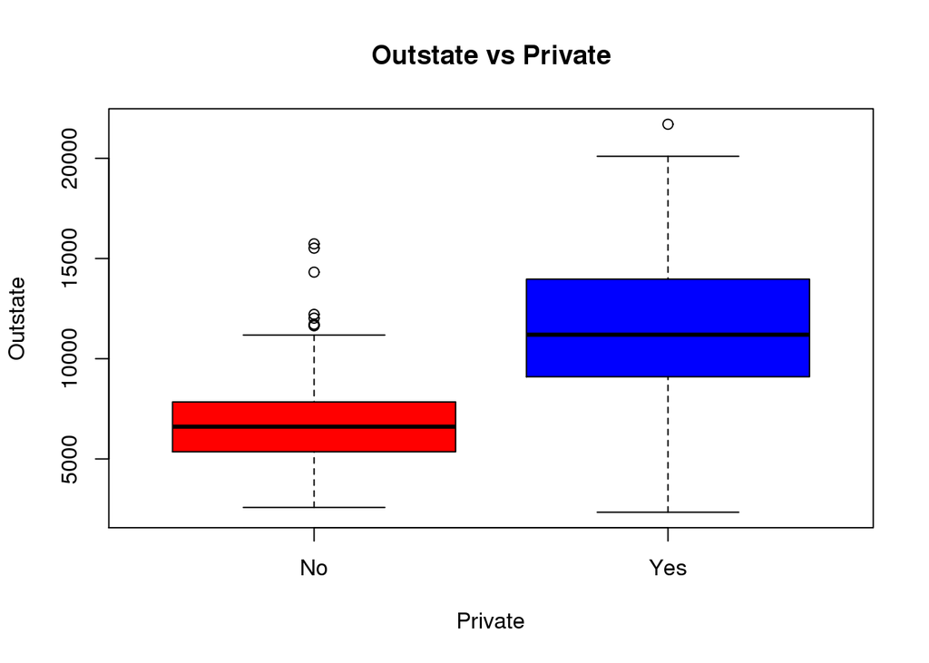

```r
boxplot(college$Outstate ~ college$Private, col=c("red", "blue"), main ="Outstate vs Private", xlab = "Private", ylab = "Outstate")
```

4. There are 78 elite colleges and 699 non-elite colleges.

```r
Elite <- rep("no", nrow(college))
Elite[college$Top10perc > 50] = "Yes"
Elite <- as.factor(Elite)
college <- data.frame(college, Elite)
summary(college)
```

```
##                             X       Private        Apps
##  Abilene Christian University:  1   No :212   Min.   :   81
##  Adelphi University          :  1   Yes:565   1st Qu.:  776
##  Adrian College              :  1             Median : 1558
##  Agnes Scott College         :  1             Mean   : 3002
##  Alaska Pacific University   :  1             3rd Qu.: 3624
##  Albertson College           :  1             Max.   :48094
##  (Other)                     :771
##      Accept          Enroll       Top10perc       Top25perc
##  Min.   :   72   Min.   :  35   Min.   : 1.00   Min.   :  9.0
##  1st Qu.:  604   1st Qu.: 242   1st Qu.:15.00   1st Qu.: 41.0
##  Median : 1110   Median : 434   Median :23.00   Median : 54.0
##  Mean   : 2019   Mean   : 780   Mean   :27.56   Mean   : 55.8
##  3rd Qu.: 2424   3rd Qu.: 902   3rd Qu.:35.00   3rd Qu.: 69.0
##  Max.   :26330   Max.   :6392   Max.   :96.00   Max.   :100.0
##
##   F.Undergrad     P.Undergrad         Outstate       Room.Board
##  Min.   :  139   Min.   :    1.0   Min.   : 2340   Min.   :1780
##  1st Qu.:  992   1st Qu.:   95.0   1st Qu.: 7320   1st Qu.:3597
##  Median : 1707   Median :  353.0   Median : 9990   Median :4200
##  Mean   : 3700   Mean   :  855.3   Mean   :10441   Mean   :4358
##  3rd Qu.: 4005   3rd Qu.:  967.0   3rd Qu.:12925   3rd Qu.:5050
##  Max.   :31643   Max.   :21836.0   Max.   :21700   Max.   :8124
##
##      Books           Personal         PhD            Terminal
##  Min.   :  96.0   Min.   : 250   Min.   :  8.00   Min.   : 24.0
##  1st Qu.: 470.0   1st Qu.: 850   1st Qu.: 62.00   1st Qu.: 71.0
##  Median : 500.0   Median :1200   Median : 75.00   Median : 82.0
##  Mean   : 549.4   Mean   :1341   Mean   : 72.66   Mean   : 79.7
##  3rd Qu.: 600.0   3rd Qu.:1700   3rd Qu.: 85.00   3rd Qu.: 92.0
##  Max.   :2340.0   Max.   :6800   Max.   :103.00   Max.   :100.0
##
##    S.F.Ratio      perc.alumni        Expend        Grad.Rate
##  Min.   : 2.50   Min.   : 0.00   Min.   : 3186   Min.   : 10.00
##  1st Qu.:11.50   1st Qu.:13.00   1st Qu.: 6751   1st Qu.: 53.00
##  Median :13.60   Median :21.00   Median : 8377   Median : 65.00
##  Mean   :14.09   Mean   :22.74   Mean   : 9660   Mean   : 65.46
##  3rd Qu.:16.50   3rd Qu.:31.00   3rd Qu.:10830   3rd Qu.: 78.00
##  Max.   :39.80   Max.   :64.00   Max.   :56233   Max.   :118.00
##
##  Elite
##  no :699
##  Yes: 78
##
##
##
##
##
```

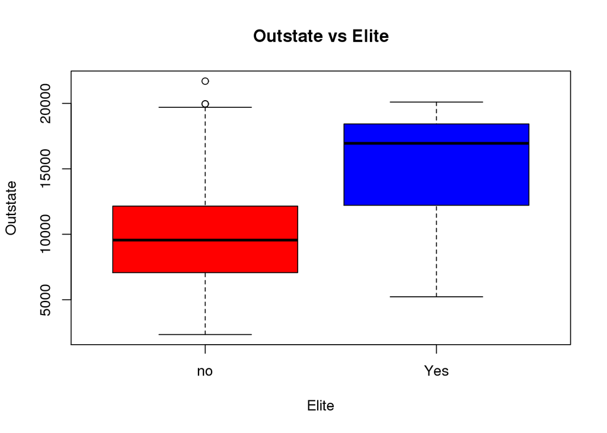

```r
boxplot(college$Outstate ~ college$Elite, col=c("red", "blue"), main ="Outstate vs Elite", xlab = "Elite", ylab = "Outstate")
```

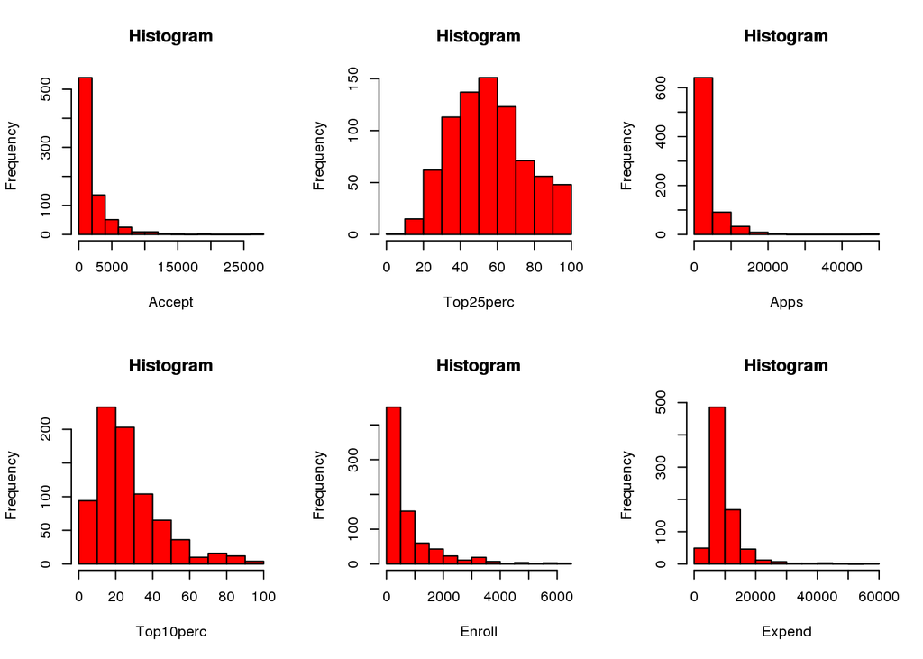

```r
par(mfcol = c(2,3))
hist(college$Accept, breaks = 10, freq = TRUE, col = "red", main = "Histogram", xlab = "Accept")
hist(college$Top10perc, breaks = 10, freq = TRUE, col = "red", main = "Histogram", xlab = "Top10perc")
hist(college$Top25perc, breaks = 10, freq = TRUE, col = "red", main = "Histogram", xlab = "Top25perc")
hist(college$Enroll, breaks = 10, freq = TRUE, col = "red", main = "Histogram", xlab = "Enroll")
hist(college$Apps, breaks = 10, freq = TRUE, col = "red", main = "Histogram", xlab = "Apps")
hist(college$Expend, breaks = 10, freq = TRUE, col = "red", main = "Histogram", xlab = "Expend")
```

```r
summary(college$Top10perc)
```

```
##    Min. 1st Qu.  Median    Mean 3rd Qu.    Max.
##    1.00   15.00   23.00   27.56   35.00   96.00
```

```r
summary(college$Top25perc)
```

```
##    Min. 1st Qu.  Median    Mean 3rd Qu.    Max.
##     9.0    41.0    54.0    55.8    69.0   100.0
```

```r
summary(college$Apps)
```

```
##    Min. 1st Qu.  Median    Mean 3rd Qu.    Max.
##      81     776    1558    3002    3624   48090
```

```r
summary(college$Accept)
```

```
##    Min. 1st Qu.  Median    Mean 3rd Qu.    Max.
##      72     604    1110    2019    2424   26330
```

### ISL 2.4.9

```r
Auto <- read.csv("/home/local/MAC/jpark2/Math-253-Assignments/Auto.csv")
Auto <- na.omit(Auto)
str(Auto)
```

```
## 'data.frame':    397 obs. of  9 variables:
##  $ mpg         : num  18 15 18 16 17 15 14 14 14 15 ...
##  $ cylinders   : int  8 8 8 8 8 8 8 8 8 8 ...
##  $ displacement: num  307 350 318 304 302 429 454 440 455 390 ...
##  $ horsepower  : Factor w/ 94 levels "?","100","102",..: 17 35 29 29 24 42 47 46 48 40 ...
##  $ weight      : int  3504 3693 3436 3433 3449 4341 4354 4312 4425 3850 ...
##  $ acceleration: num  12 11.5 11 12 10.5 10 9 8.5 10 8.5 ...
##  $ year        : int  70 70 70 70 70 70 70 70 70 70 ...
##  $ origin      : int  1 1 1 1 1 1 1 1 1 1 ...
##  $ name        : Factor w/ 304 levels "amc ambassador brougham",..: 49 36 231 14 161 141 54 223 241 2 ...
```

1. Quantitative Predictors: mpg, cylinders, displacement, weight, acceleration, year, origin

Qualitatitive Predictors: horsepower, name

```r
range(Auto$mpg)
```

```
## [1]  9.0 46.6
```

```r
range(Auto$cylinders)
```

```
## [1] 3 8
```

```r
range(Auto$displacement)
```

```
## [1]  68 455
```

```r
range(Auto$weight)
```

```
## [1] 1613 5140
```

```r
range(Auto$acceleration)
```

```
## [1]  8.0 24.8
```

```r
range(Auto$year)
```

```
## [1] 70 82
```

```r
range(Auto$origin)
```

```
## [1] 1 3
```

Range of mpg: (9, 46.6) Range of cylinders: (3, 8)

Range of displacement: (68, 455)

Range of weight: (1613, 5140)

Range of acceleration: (8, 24.8)

Range of year: (70, 82)

Range of origin: (1, 3)

```r
sapply(Auto[, -c(4,9)], mean)
```

```
##          mpg    cylinders displacement       weight acceleration
##    23.515869     5.458438   193.532746  2970.261965    15.555668
##         year       origin
##    75.994962     1.574307
```

```r
sapply(Auto[, -c(4,9)], sd)
```

```
##          mpg    cylinders displacement       weight acceleration
##    7.8258039    1.7015770  104.3795833  847.9041195    2.7499953
##         year       origin
##    3.6900049    0.8025495
```

```r
auto2 <- Auto[-c(10:85), -c(4,9)]
sapply(auto2, range)
```

```
##       mpg cylinders displacement weight acceleration year origin
## [1,] 11.0         3           68   1649          8.5   70      1
## [2,] 46.6         8          455   4997         24.8   82      3
```

```r
sapply(auto2, mean)
```

```
##          mpg    cylinders displacement       weight acceleration
##    24.438629     5.370717   187.049844  2933.962617    15.723053
##         year       origin
##    77.152648     1.598131
```

```r
sapply(auto2, sd)
```

```
##          mpg    cylinders displacement       weight acceleration
##    7.9081842    1.6534857   99.6353853  810.6429384    2.6805138
##         year       origin
##    3.1112298    0.8161627
```

Range of mpg: [11.0, 46.6]

Range of cylinders: [3, 8]

Range of displacement: [68, 455]

Range of weight: [1649, 4997]

Range of acceleration: [8.5, 24.8]

Range of year: [70, 82]

Range of origin: [1, 3]

# =========================================

Mean of mpg: 24.438629

Mean of cylinders: 5.370717

Mean of displacement: 187.049844

Mean of weight: 2933.962617

Mean of acceleration: 15.723053

Mean of year: 77.152648

Mean of origin: 1.598131

# =======================================

sd of mpg: 7.9081842

sd of cylinder: 1.6534857

sd of displacement: 99.6353853

sd of weight: 810.642984

sd of acceleration: 2.6805138

sd of year: 3.1112298

sd of origin: 0.8161627

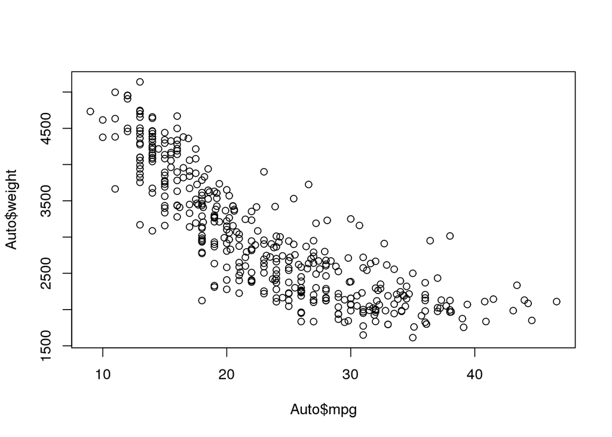

```r
plot(Auto$mpg, Auto$weight)
```

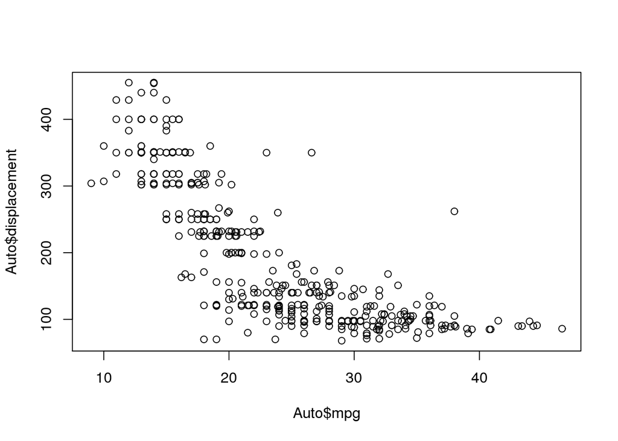

```r
plot(Auto$mpg, Auto$displacement)
```

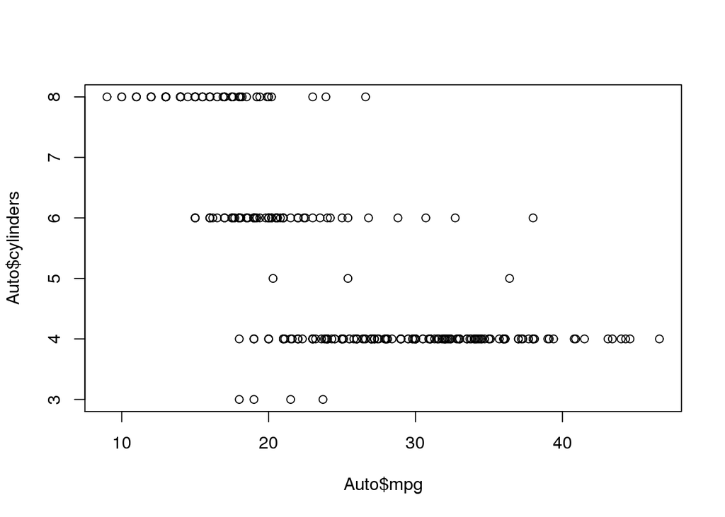

```r
plot(Auto$mpg, Auto$cylinders)
```

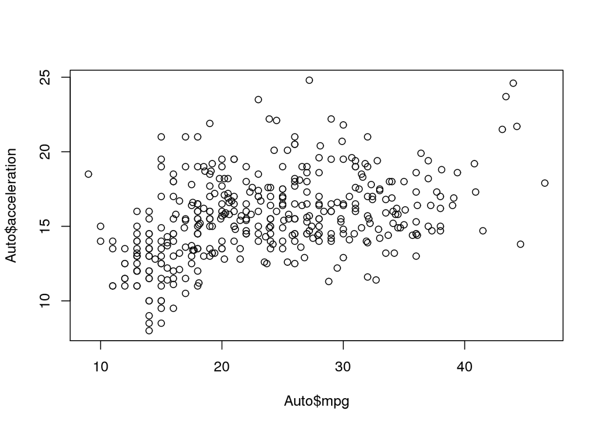

```r
plot(Auto$mpg, Auto$acceleration)
```

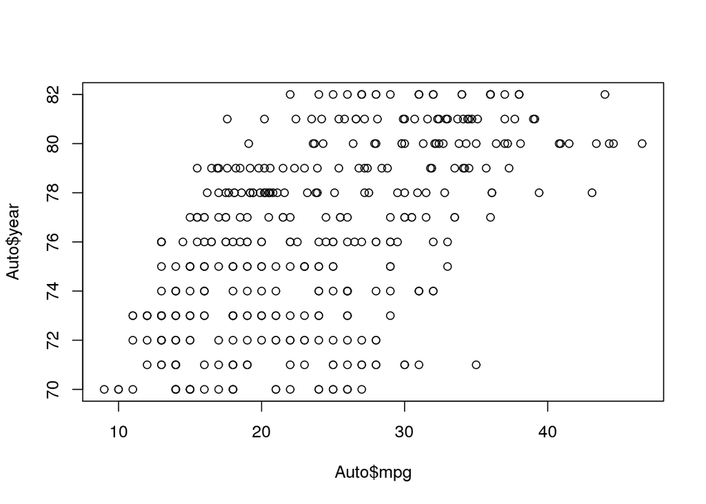

```r
plot(Auto$mpg, Auto$year)
```

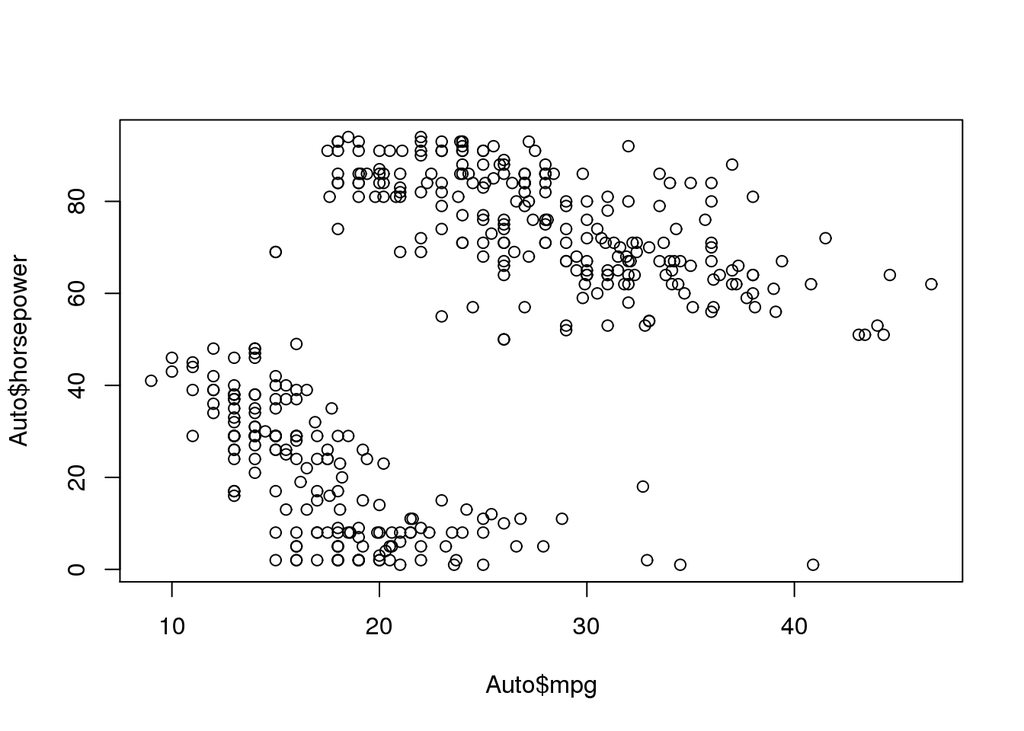

```r
plot(Auto$mpg, Auto$horsepower)
```

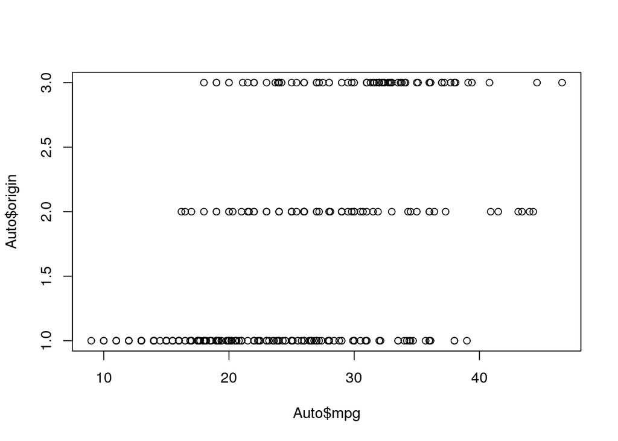

```r
plot(Auto$mpg, Auto$origin)
```

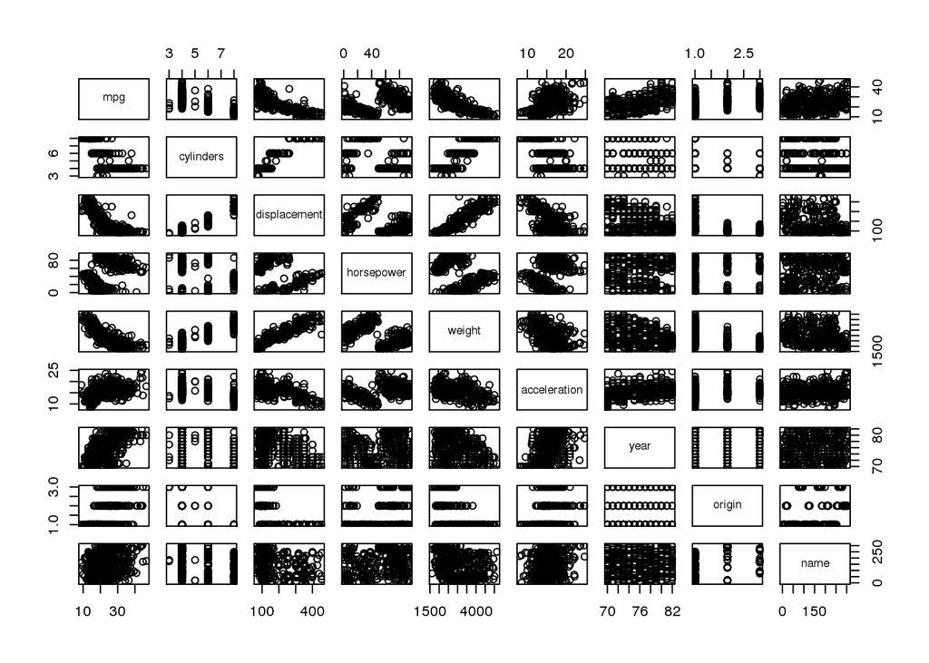

```r
pairs(Auto)
```

There seems to be an inverse relationship between weight and mpg of cars (i.e. the greater the weight of a car, the lower the mpg). There also seems to be an inverse relationship between displacement and mpg of cars.

## Theory Assignment

### ISL 2.4.2

1. Regression problem because the response variable is quantitative. We would be most interested in inference because we want to know which factors affect the CEO salary (n = 500, p = 3).
2. Classification problem because the response variable is qualitative. We would be most interested in prediction because we predict whether the new product will be a success or a failure depending on the other variables (n = 20, p = 13).
3. Regression problem because the response variable is quantitative. We would be most interested in prediction because we are predicting the % change in the US dollar depending on the changes in the world stock markets (n = 52, p = 3).

### ISL 2.4.7

1. Euclidean distance

Obs. 1: sqrt((0-0)^2 + (0-3)^2) + (0-0)^2) = 3

Obs. 2: sqrt((0-2)^2 + (0-0)^2 + (0-0)^2) = 2

Obs. 3: sqrt((0-0)^2 + (0-1)^2 + (0-3)^2) = sqrt(10) = 3.1623

Obs. 4: sqrt((0-0)^2 + (0-1)^2 + (0-2)^2) = sqrt(5) = 2.2361

Obs. 5 = sqrt((0-(-1))^2 + (0-0)^2 + (0-1)^2) = sqrt(2) = 1.4142

Obs. 6 = sqrt((0-1)^2 + (0-1)^2 + (0-1)^2) = sqrt(3) = 1.7321